# MSA8190-HW6

## Problem 5

The compressive strength of concrete is being tested by a civil engineer. He tests 12 specimens and obtains the following data.

```r
d5<-c(2216,2237,2225,2301,2318,2255,2249,2204,2281,2263,2275,2295)
n<-12
```

### (a) Is there evidence to support the assumption that compressive strength is normally distributed? Does this data set support your point of view? Include a graphical display in your answer.

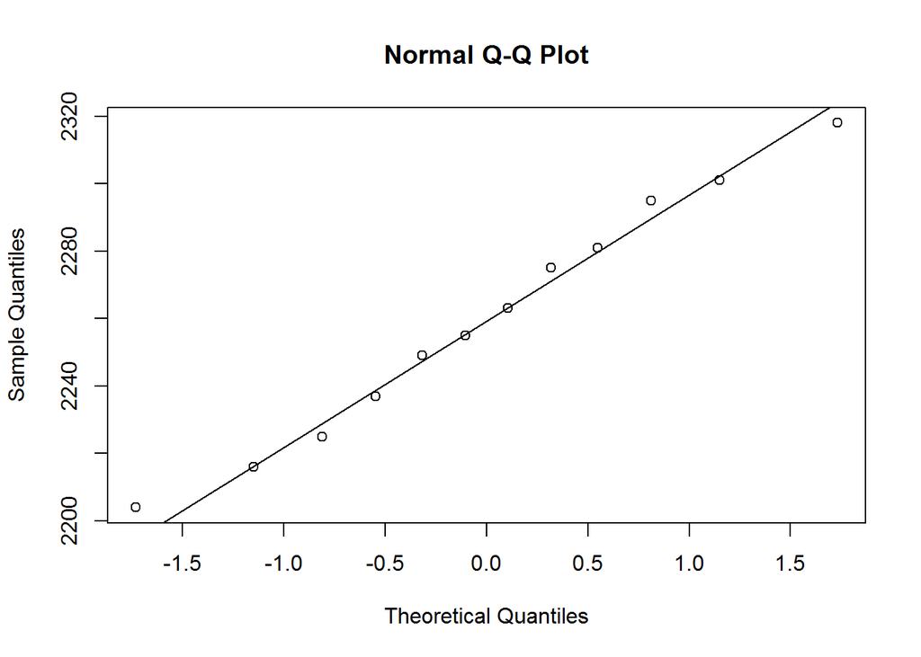

```r
x_bar<-mean(d5)
s<-sd(d5)

alpha<-0.05
qqnorm(d5); qqline(d5)
```

Yes, the data seens to follow a normal distribution. The probability plot is very accurate close to the 0 quantile and varies more the farther out you go.

### (b) Test the normality of the data by Shapiro-Wilk test?

```r
shapiro.test(d5)
```

```
##
##  Shapiro-Wilk normality test
##
## data:  d5
## W = 0.97909, p-value = 0.9798
```

The test gives a very high p value, much larger than any normal alpha, so we can not reject that this has a normal distribution.

### (c) Construct a 95% two-sided confidence interval on the mean strength.

```r
ta<-qt(0.025, n-1, lower.tail=FALSE)
cil<-x_bar-(ta*(s/sqrt(n)))
ciu<-x_bar+(ta*(s/sqrt(n)))
```

The confidence interval is [2237.3170193, 2282.516314].

### (d) Construct a 95% lower-confidence bound on the mean strength.

```r
ta<-qt(0.05, n-1, lower.tail=FALSE)
cil<-x_bar-(ta*(s/sqrt(n)))
```

The confidence interval is [2241.4765771, ].

## Problem 6

The sugar content of the syrup in canned peaches is normally distributed. Suppose that the variance is thought to be sigma^2 = 18 (milligrams). A random sample of n = 10 cans yields a sample standard deviation of s = 4.8 milligrams.

```r
var<-18
n<-10
s<-4.8
```

### (a) Test the hypothesis H0 : sigma^2 = 18 versus H1 : sigma^2 != 18 using alpha = 0.05.

Have to check both sides since not symmetric

```r
alpha<-0.05
chi20<-(((n-1)*s^2)/var)
chia2l<-qchisq(alpha/2,n-1)
chia2u<-qchisq(alpha/2,n-1, lower.tail=FALSE)
chi20>chia2u
```

```
## [1] FALSE
```

```r
chi20<chia2l
```

```
## [1] FALSE
```

Since it is not smaller than the lower bound or larger than the upper bound, we can not reject the null hypothesis.

### (b) What is the P-value for this test?

```r
2*(1-pchisq(chi20, n-1))
```

```
## [1] 0.4834818
```

### (c) Find a 95% two-sided confidence interval for sigma.

```r
clb<-(((n-1)*s^2)/chia2u)
cub<-(((n-1)*s^2)/chia2l)
```

The confidence interval is [10.9006219, 76.7889225].

### (d) Find a 90% lower confidence bound for sigma.

```r
(((n-1)*s^2)/qchisq(0.1,n-1, lower.tail=FALSE))
```

```
## [1] 14.12182
```

### (e) Discuss how part (a) could be answered by constructing a 95% two-sided confidence interval for sigma.

The hypothesis could also be tested by conducting a confidence interval using the sample variance. If the expected value of the variance falls outside of the interval then the hypothesis is rejected.

### (f) Suppose that the true variance is sigma2 = 40. How large a sample would be required to detect this difference with probability at least 0.90?

```r
lambda<-sqrt(40)/s
B<-0.90
pwr.chisq.test(w=lambda, df=n-1, sig.level=alpha/2, power=B)
```

```
##
##      Chi squared power calculation
##
##               w = 1.317616
##               N = 13.045
##              df = 9
##       sig.level = 0.025
##           power = 0.9
##
## NOTE: N is the number of observations
```

## Problem 7

The rainfall in acre-feet from 20 clouds that were selected at random and seeded with silver nitrate follows:

```r
d7<-c(18.0,30.7,19.8,27.1,22.3,18.8,31.8,23.4,21.2,27.9,31.9,27.1,25.0,24.7,26.9,21.8,29.2,34.8,26.7,31.6)
n<-20
x_bar<-mean(d7)
s<-sd(d7)
```

### (a) Can you support a claim that mean rainfall from seeded clouds exceeds 25 acre-feet? Use alpha = 0.01.

H0:x=25 H1:x>25

```r
alpha<-0.01
x0<-25
t0<-(x_bar-x0)/(s/sqrt(n))
ta<-qt(alpha, n-1)
t0>ta
```

```
## [1] TRUE
```

### (b) Is there evidence that rainfall is normally distributed?

```r
shapiro.test(d7)
```

```
##
##  Shapiro-Wilk normality test
##
## data:  d7
## W = 0.97025, p-value = 0.7601
```

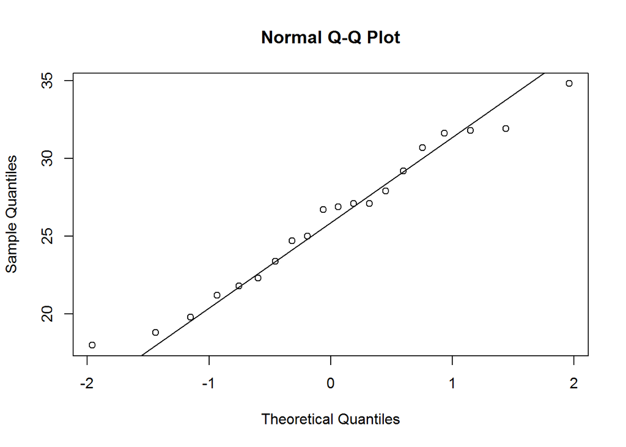

```r
qqnorm(d7); qqline(d7)
```

With alpha as 0.01 then we can’t reject from the shapiro test and the probability plot shows a normal distribution fits relatively well.

### (c) Compute the power of the test if the true mean rainfall is 27 acre-feet.

```r
d<-(27-x_bar)/s
pwr.norm.test(d=d,sig.level=alpha, n=n)
```

```
##
##      Mean power calculation for normal distribution with known variance
##
##               d = 0.2016818
##               n = 20
##       sig.level = 0.01
##           power = 0.0473298
##     alternative = two.sided
```

### (d) What sample size would be required to detect a true mean rainfall of 27.5 acre-feet if we wanted the power of the test to be at least 0.9?

```r
d<-(27.5-x_bar)/s
pwr.norm.test(d=d,sig.level=alpha, power=0.9)
```

```
##
##      Mean power calculation for normal distribution with known variance
##
##               d = 0.3061802
##               n = 158.7198
##       sig.level = 0.01
##           power = 0.9
##     alternative = two.sided
```

n=158.7 so 159 samples

### (e) Explain how the question in part (a) could be answered by constructing a one-sided confidence bound on the mean diameter.

```r
ta<-qt(alpha, n-1)
ci<-x_bar-(ta*(s/sqrt(n)))
x0>ci
```

```
## [1] FALSE
```

### (f) Explain how the question in part (a) could be answered by using p-value.

u>25

```r
p<-pt(t0, n-1, lower.tail=FALSE)
p<alpha
```

```
## [1] FALSE
```

Since p<alpha is false we can not reject the hypothesis that mean=25.

## Problem 8

The sodium content of thirty 300-gram boxes of organic corn flakes was determined. The data (in milligrams) are as follows:

```r
d8<-c(131.15,130.69,130.91,129.54,129.64,128.77,130.72,128.33,128.24,129.65,130.14,129.29,128.71,129.00,129.39,130.42,129.53,130.12,129.78,130.92,131.15,130.69,130.91,129.54,129.64,128.77,130.72,128.33,128.24,129.65)
n<-30
x_bar<-mean(d8)
s<-sd(d8)
```

### (a) Can you support a claim that mean sodium content of this brand of corn flakes is 130 milligrams? Use alpha = 0.05. h0:u=130, h1:u!=130

```r
alpha <- 0.05
u0<-130
t0<-(x_bar-u0)/(s/sqrt(n))
ta<-qt(alpha/2, n-1, lower.tail=FALSE)
abs(t0)>ta
```

```
## [1] FALSE
```

Since the result is false we can not reject the hypothesis, so we can support the claim that mean = 130mg.

### (b) Is there evidence that sodium content is normally distributed?

```r
shapiro.test(d8)
```

```
##
##  Shapiro-Wilk normality test
##
## data:  d8
## W = 0.9335, p-value = 0.06088
```

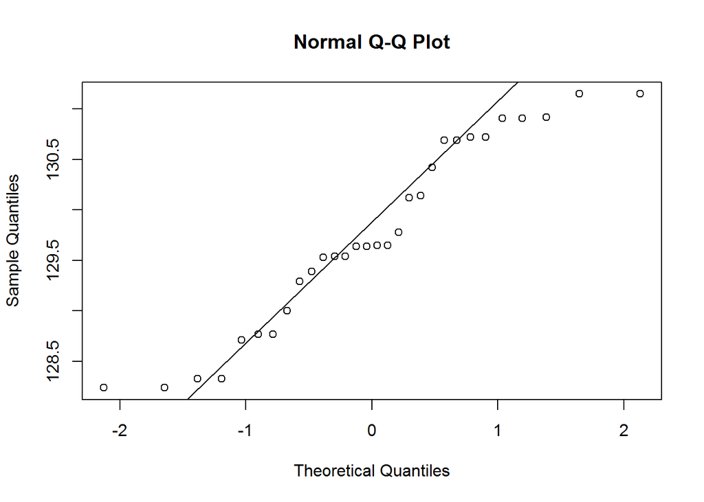

```r
qqnorm(d8); qqline(d8)
```

### (c) Compute the power of the test if the true mean sodium content is 130.5 miligrams.

```r
d<-(130.5-x_bar)/s
pwr.t.test(d=d,sig.level=alpha, n=n)
```

```
##
##      Two-sample t test power calculation
##
##               n = 30
##               d = 0.8041377
##       sig.level = 0.05
##           power = 0.8648747
##     alternative = two.sided
##
## NOTE: n is number in *each* group
```

### (d) What sample size would be required to detect a true mean sodium content of 130.1 milligrams if we wanted the power of the test to be at least 0.75?

```r
d<-(130.1-x_bar)/s
pwr.t.test(d=d,sig.level=alpha, power=0.75)
```

```
##
##      Two-sample t test power calculation
##
##               n = 100.3457
##               d = 0.3737339
##       sig.level = 0.05
##           power = 0.75
##     alternative = two.sided
##
## NOTE: n is number in *each* group
```

n=100.35, so 101 samples would be needed.

### (e) Explain how the question in part (a) could be answered by constructing a two-sided confidence interval on the mean sodium content.

```r
ci<-x_bar-(ta*(s/sqrt(n)))
ci2<-x_bar+(ta*(s/sqrt(n)))
```

A confidence interval is calculated to be [129.405638, 130.0996954]. If the test mean falls within this interval, then the null hypothesis can not be rejected. Since our value falls within we can not reject the hypothesis.

### (f) Explain how the question in part (a) could be answered by using p-value.

```r
p<-2*(pt(t0, n-1, lower.tail=FALSE))
p<alpha
```

```
## [1] FALSE
```

Since p<alpha is false we can not reject the hypothesis.

## Problem 9

A researcher claims that at least 10% of all football helmets have manufacturing flaws that could potentially cause injury to the wearer. A sample of 200 helmets revealed that 16 helmets contained such defects.

```r
p0<-0.10
n<-200
p_bar<-16/200
```

### (a) Does this finding support the researcher’s claim? Use alpha = 0.01. h0:p=0.10, h1:p<0.10

```r
alpha<-0.01
z0<-(p_bar-p0)/sqrt((p0*(1-p0))/n)
za<-qnorm(1-alpha)
z0< -za
```

```
## [1] FALSE
```

Since false, we can not reject the researcher’s claim that at least 10% of all helmets have flaws.

### (b) Find the P-value for this test.

```r
p<-pnorm(z0, lower.tail=FALSE)
p<alpha
```

```
## [1] FALSE
```

Since is false we can not reject the hypothesis.

## Problem 10

The advertised claim for batteries for cell phones is set at 48 operating hours, with proper charging procedures. A study of 5000 batteries is carried out and 15 stop operating prior to 48 hours. Do these experimental results support the claim that less than 0.2 percent of the company’s batteries will fail during the advertized time period, with proper charging procedures? Use a hypothesis-testing procedure with alpha = 0.01. h0: p=0.002, h1:p>0.002

```r
alpha<-0.01
n<-5000
x_bar<-15
p0<-0.002
p_bar<-x_bar/n
z0<-(p_bar-p0)/sqrt((p0*(1-p0))/n)
za<-qnorm(1-alpha)
z0< -za
```

```
## [1] FALSE
```

```r
pnorm(z0)
```

```
## [1] 0.9432576
```

Since the test statistic is not less than the z , we fail to reject the null hypothesis.

## Problem 11

Consider the following 75 observations.

```r
d11<-c(2,3,1,0,0,0,1,1,1,0,1,1,2,1,1,2,0,0,1,1,2,4,0,1,1,2,3,1,0,0,0,0,1,2,0,0,2,2,2,2,2,1,0,0,2,0,0,1,0,0,2,3,1,2,0,4,1,1,0,2,3,1,1,0,0,2,1,3,0,2,1,1,1,0,0)
```

Based on this data, is a Poisson distribution an appropriate model?

```r
freq<-as.data.frame(table(d11))
lambda<-((0*freq[1, 2])+(1*freq[2, 2])+(2*freq[3, 2])+(3*freq[4, 2])+(4*freq[5, 2]))/75
freq$efreq<-c(dpois(0,lambda)*75, dpois(1,lambda)*75, dpois(2,lambda)*75, dpois(3,lambda)*75,dpois(4,lambda)*75)
freq
```

```
##   d11 Freq     efreq
## 1   0   26 25.132323
## 2   1   25 27.478006
## 3   2   17 15.021310
## 4   3    5  5.474433
## 5   4    2  1.496345
```

```r
k<-4
dof<-k-1-1
chi20<-(((freq$Freq[1]-freq$efreq[1])^2/freq$efreq[1])+((freq$Freq[2]-freq$efreq[2])^2/freq$efreq[2])+((freq$Freq[3]-freq$efreq[3])^2/freq$efreq[3])+(((freq$Freq[4]+freq$Freq[5])-(freq$efreq[4]+freq$efreq[4]))^2/(freq$efreq[4]+freq$efreq[4])))
chi2a<-qchisq(0.05,dof)
chi20>chi2a
```

```
## [1] TRUE
```

No, since chi20 > chi2a we reject the null hypothesis that the distrubution is poisson.

## Problem 12

Use the following 60 observations.

```r
d12<-c(107.20,102.87,109.85,103.37,105.16,93.71,99.05,96.96,92.30,105.36,91.38,113.37,81.19,100.71,90.80,121.75,104.78,94.85,83.65,91.93,101.49,105.57,99.24,98.94,100.42,112.15,99.41,83.20,89.52,108.96,107.78,99.79,98.99,85.94,101.03,102.62,96.50,89.35,108.82,106.07,109.11,88.68,101.44,98.70,95.82,93.14,101.10,115.03,126.73,109.71,97.90,109.03,109.97,100.38,104.57,91.03,91.35,94.60,100.26,103.60)
n<-60
```

### Based on this data, is a normal distribution an appropriate model? To check this do the following:

### (a) Plot the normal probability plot for this data.

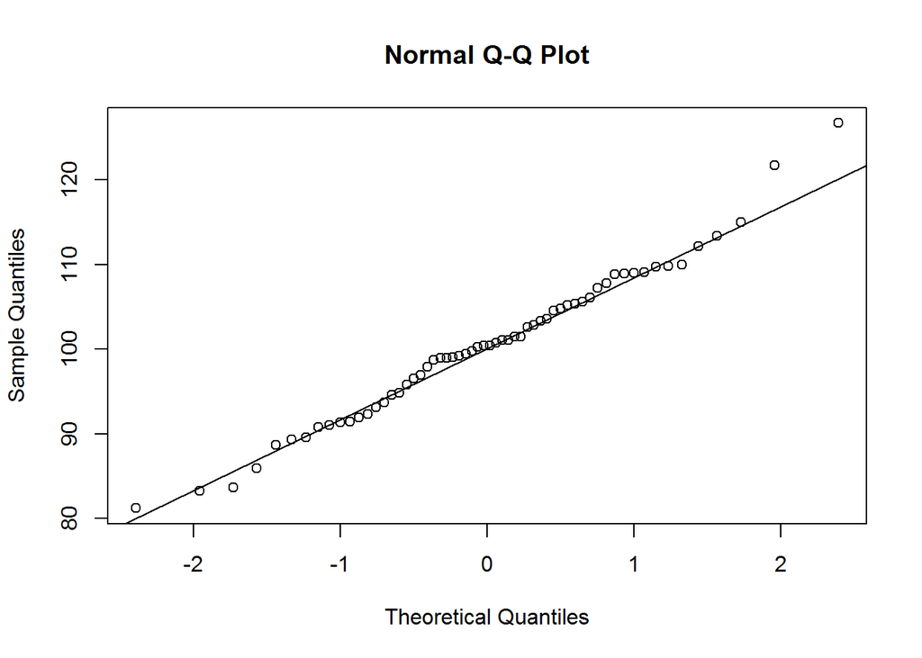

```r
qqnorm(d12); qqline(d12)
```

### (c) Use Shapiro-Wilk test.

```r
shapiro.test(d12)
```

```
##
##  Shapiro-Wilk normality test
##
## data:  d12
## W = 0.98521, p-value = 0.6811
```

## Problem 13

Use the following 100 observations.

```r
d13<-c(7.08,19.33,2.36,15.61,9.73,3.86,5.23,7.36,17.62,11.27,47.93,0.39,68.18,14.60,34.61,18.79,9.67,13.82,12.02,4.81,6.69,20.26,20.97,0.12,1.50,2.19,1.11,21.18,0.78,13.63,14.77,9.41,9.27,5.21,8.37,16.81,0.12,5.55,7.71,3.28,7.01,7.29,5.33,1.84,30.61,13.41,10.28,6.21,14.30,0.55,62.21,3.49,0.15,9.36,3.78,2.64,18.79,4.37,35.40,2.63,2.59,9.17,6.97,0.91,1.02,2.19,3.27,15.29,5.24,3.79,0.45,5.64,0.36,2.61,35.01,7.65,12.00,3.43,39.58,17.65,15.55,14.66,0.37,3.02,49.43,14.70,0.42,34.84,2.42,10.54,15.19,15.13,15.37,17.79,22.65,2.31,12.34,12.28,22.88,0.15)
n<-100
```

### (a) Use normal probability plot, chi square goodness of fit test, and Shapiro-Wilk test to check normality of data.

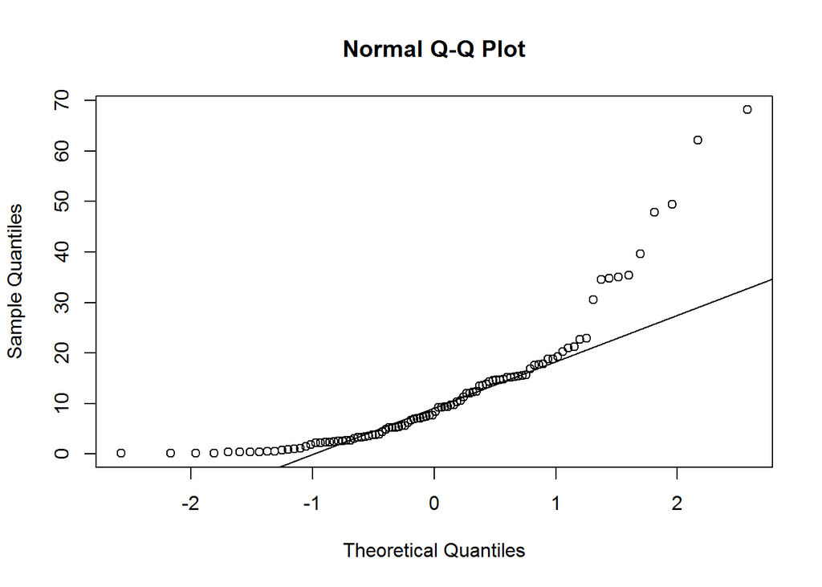

```r
x_bar<-mean(d13)
s<-sd(d13)
alpha<-0.05
qqnorm(d13); qqline(d13)
```

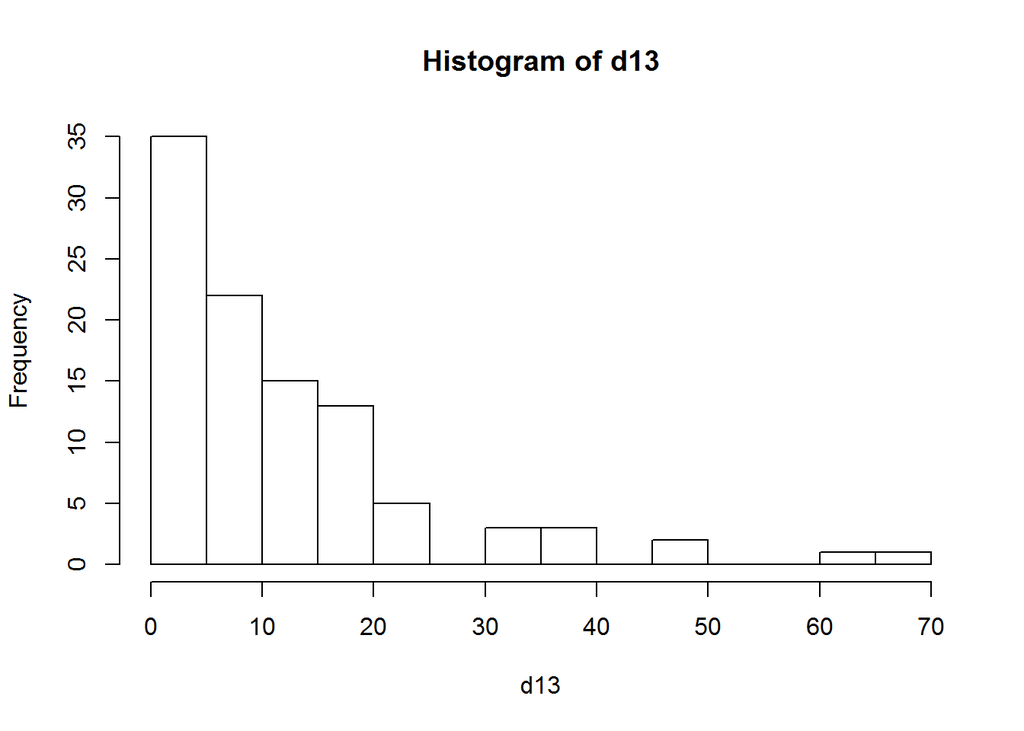

```r
hist<-hist(d13, breaks=10)
```

```r
k<-10
breaks_cdf <- pgamma(hist$breaks, shape=1/2, scale=(k-1-1)/2)
probs <- rollapply(breaks_cdf, 2, function(x) x[2]-x[1])
chisq.test(hist$counts, p=probs, rescale.p=TRUE, simulate.p.value=TRUE)
```

```
##
##  Chi-squared test for given probabilities with simulated p-value
##  (based on 2000 replicates)
##
## data:  hist$counts
## X-squared = 1511700, df = NA, p-value = 0.0004998
```

```r
shapiro.test(d13)
```

```
##
##  Shapiro-Wilk normality test
##
## data:  d13
## W = 0.77602, p-value = 4.842e-11
```

All three tests show this data set is not a good fit.

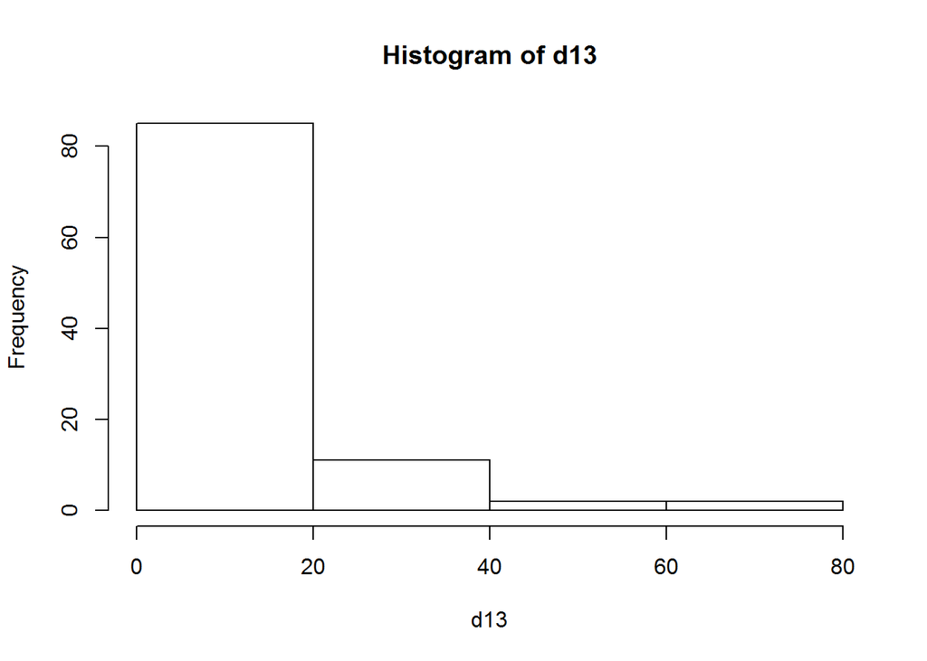

```r
hist<-hist(d13, breaks=4)
```

```r
k<-4
breaks_cdf <- pexp(hist$breaks, x_bar)
probs <- rollapply(breaks_cdf, 2, function(x) x[2]-x[1])
chisq.test(hist$counts, p=probs, rescale.p=TRUE, simulate.p.value=TRUE)
```

```
##
##  Chi-squared test for given probabilities with simulated p-value
##  (based on 2000 replicates)
##
## data:  hist$counts
## X-squared = Inf, df = NA, p-value = NA
```